# [Lecture Note] Topic Modeling: Comprehensive Explanations

Make up and special topic

Author

Chad (Chungil Chae)

Published

Tue, 27 May 2025

# Learning Objectives

- Topic model concept
- Implemetation
- Topic interpretation
- Advanced model
- Application

## SHORT VIDEO INTRODUCTION

[video not shown]

# Introduction

## What is Topic Modeling?

- **Definition**: Topic modeling is an unsupervised machine learning technique that discovers abstract “topics” that occur in a collection of documents. It doesn’t require pre-labeled data, making it powerful for exploratory analysis.
- **Core idea**: Elaborate that each document contains multiple topics in different proportions (like 30% politics, 50% economics, 20% healthcare), and each topic is characterized by a distribution over words (e.g., the “economics” topic might give high probability to words like “market,” “inflation,” “GDP”).
- **Goal**: Emphasize that topic modeling helps us understand large text collections by revealing underlying thematic structures. For example, analyzing thousands of news articles to understand main themes without reading each one.
- Give a concrete example: “Imagine having 10,000 customer reviews. Rather than reading each one, topic modeling might show that 30% discuss product quality, 25% discuss shipping issues, 20% discuss customer service, etc.”

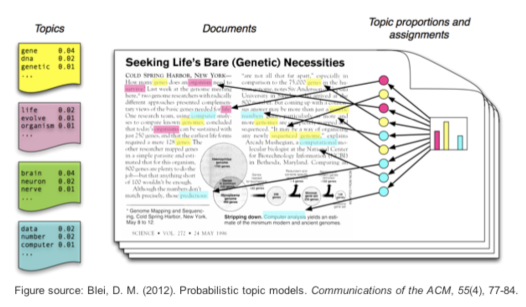

## Historical Context

- **Origins**: Explain how information retrieval problems (like searching large document collections) led to the development of these methods.
- Milestone developments:
  - Describe LSA as the first attempt to capture semantic meaning beyond exact keyword matching using matrix factorization.
  - Explain how pLSA improved on LSA by introducing a proper probabilistic model but still had limitations with new documents.
  - Highlight LDA as the breakthrough that addressed pLSA’s limitations by adding Dirichlet priors, becoming the standard approach.
  - Mention that recent neural approaches are extending these foundations with deep learning capabilities.
- Connect this history to the broader evolution of text analytics, showing how topic modeling fits into the progression from simple keyword counting to sophisticated semantic analysis.

## Why Topic Modeling Matters

- **Document organization**: Show examples of how digital libraries or enterprise document systems use topic modeling to automatically categorize thousands of documents.
- **Information retrieval**: Explain how Google Scholar might use topic modeling to improve academic paper search, allowing users to find conceptually related papers even when they use different terminology.
- **Content recommendation**: Describe how Netflix or Spotify might leverage topic models to understand content and user preferences at a thematic level.
- **Knowledge discovery**: Show examples like analyzing medical literature to discover connections between seemingly unrelated research areas.
- **Dimensionality reduction**: Explain the technical advantage of reducing thousands of word dimensions to a small number of topic dimensions while preserving semantic relationships.
- Include a real-world example: “Researchers used topic modeling on 17,000 New York Times articles to track how COVID-19 discourse evolved from a health crisis to an economic and political issue.”

# Theoretical Foundation

## Text Representation

- **Bag-of-words approach**: Explain that word order is discarded, and documents are represented as word frequency counts. Show a simple example converting a sentence to this representation.
- Document-term matrix: Use a visual example showing a small corpus of 3-4 documents and how they’d be represented in this matrix format.
  - For example, show how documents like “I love machine learning”, “I love deep learning”, and “Deep learning is fascinating” would be represented in a matrix.
  - Demonstrate how sparse this matrix becomes with real-world data (mostly zeros).

[figure not shown]

- Challenges:
  - Illustrate sparsity with statistics (e.g., “A corpus of 10,000 news articles might have 50,000 unique terms, but each document uses only 100-200 of them”).
  - Explain how high dimensionality leads to computational challenges and the “curse of dimensionality.”
  - Discuss how semantically related words like “car” and “automobile” are treated as completely different dimensions in this representation.

## Probabilistic Modeling Concepts

- **Generative models**: Use the cooking analogy: “Imagine reverse-engineering recipes (topics) from final dishes (documents). We observe the dishes and try to figure out what ingredients (words) went into each recipe and in what proportions.”
- **Latent variables**: Explain that topics are hidden/latent because we don’t observe them directly in the text; we only see words and must infer the underlying topics.
- Distributions: Use visual examples showing:
  - How a document might be distributed across topics (e.g., 70% sports, 30% business)
  - How a topic might be distributed across words (e.g., the sports topic gives high probability to “team,” “player,” “game,” etc.)
- Key probability distributions :
  - Explain the multinomial distribution as a generalization of the coin flip to multiple outcomes (like rolling a die).
  - Describe the Dirichlet distribution as a “distribution over distributions” that controls how concentrated or spread out topic mixtures tend to be.
  - Show visualizations of how different Dirichlet parameters create different distribution patterns.

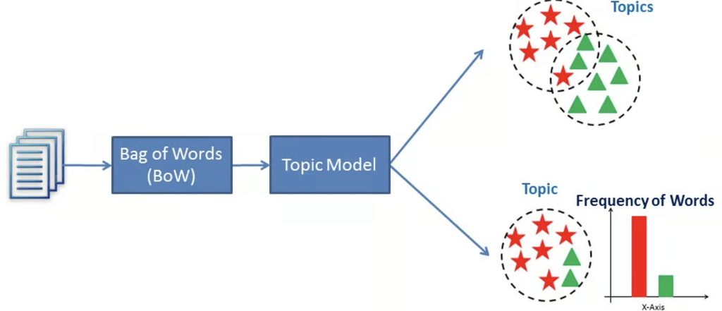

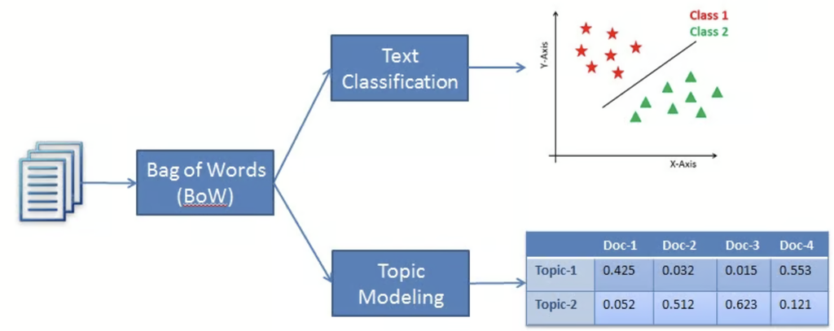

## Latent Dirichlet Allocation (LDA)

- **Core assumption**: Elaborate on the mixed membership model - unlike hard clustering, documents aren’t assigned to single topics but have proportions of multiple topics.

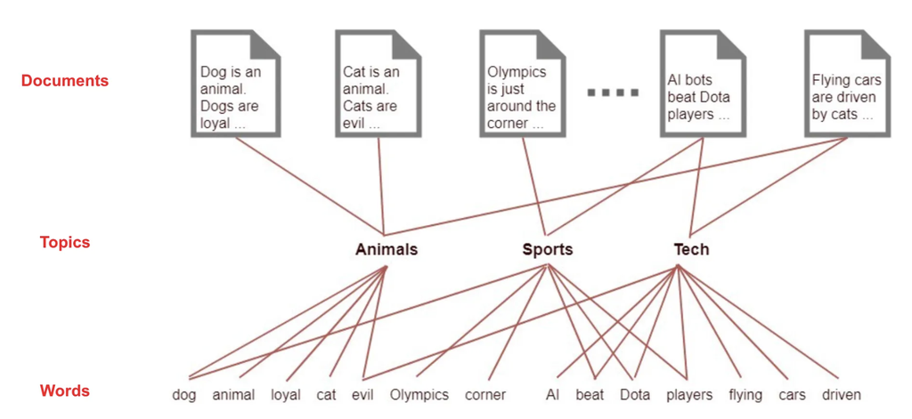

## Other Topic Modeling Approaches

- Latent Semantic Analysis (LSA):
  - Explain singular value decomposition (SVD) in intuitive terms as finding the most important dimensions of variation in the document-term matrix.
  - Show how truncating the SVD creates a low-rank approximation that captures the most important semantic patterns.
  - Use a visual example of dimensionality reduction from word space to topic space.
- Non-Negative Matrix Factorization (NMF):
  - Explain the intuition: decomposing the document-term matrix into two non-negative matrices (document-topic and topic-word).
  - Highlight why non-negativity is semantically meaningful for topic modeling (can’t have negative amounts of topics).
- Comparison table: For each method, cover:
  - Mathematical foundation (matrix factorization vs probabilistic modeling)
  - Interpretability of results
  - Computational requirements
  - Handling of new documents
  - Theoretical guarantees
  - When each might be preferred

# LDA Deep Dive

## LDA Intuition

- Two probability distributions:
  - Use concrete examples showing what these distributions look like in practice.
  - For θ (theta), show a bar chart of topic proportions for a specific document.
  - For φ (phi), show word clouds or probability tables for specific topics.
- Metaphor: Expand on the recipe book metaphor:
  - Topics are like recipes (instructions for combining ingredients)
  - Documents are like dishes made by mixing multiple recipes
  - Words are like ingredients that appear in various recipes
  - When we observe only the final dishes (documents), LDA helps us recover the original recipes (topics)
- Animation: When discussing the animation, walk through:
  1. How topic proportions are first sampled for a document
  2. How words are then generated by repeatedly sampling topics and then words from those topics
  3. How this creates word co-occurrence patterns that LDA can detect

## LDA Parameters

- K: Discuss the importance of choosing an appropriate number of topics:
  - Too few topics: Important distinctions get merged (e.g., “science” topic might merge physics, biology, chemistry)
  - Too many topics: Single coherent themes get fragmented (e.g., “physics” might split into multiple redundant topics)
  - Explain that this is a model selection problem, and there’s no single “correct” number
- α (alpha): Use visualizations to show:
  - Low alpha values (e.g., 0.1) create sparse document-topic distributions where documents focus on few topics
  - High alpha values (e.g., 50) create more uniform distributions where documents contain many topics
  - Explain when each setting might be appropriate (e.g., low alpha for specialized documents, high alpha for diverse documents)
- β (beta): Similarly, use visualizations to show:
  - Low beta values create topics focused on few distinctive words
  - High beta values create topics that spread probability across many words
  - Explain that most implementations use symmetric Dirichlet priors (same alpha for all topics, same beta for all words)

## LDA Generative Process

1. **Choose θ ~ Dirichlet(α) for each document**: Explain that this step determines the topic mixture for each document. Use a visual example of sampling from a Dirichlet distribution to get a topic proportion vector.
2. **Choose φ ~ Dirichlet(β) for each topic**: Explain that this step determines the word distribution for each topic. Show visually how each topic gets its own probability distribution over the vocabulary.
3. For each word position in each document:
   - **Choose a topic z ~ Multinomial(θ)**: Explain this as picking a topic based on the document’s topic proportions (like spinning a weighted roulette wheel).
   - **Choose a word w ~ Multinomial(φ_z)**: Explain this as picking a word from the selected topic’s word distribution (spinning another weighted roulette wheel).
4. Visual representation: Walk through an animated example showing:
   - A document with 3 topics (70% science, 20% politics, 10% sports)
   - For each word position, show topic selection based on these proportions
   - Then show word selection from the chosen topic
   - Gradually build up the complete document

[figure not shown]

## Inference Methods

- **Problem**: Emphasize that in practice, we observe documents (words) but not topics, so we need to work backward through the generative process (posterior inference).
- Collapsed Gibbs Sampling:
  - Explain the intuitive process: repeatedly going through each word in each document and reassigning its topic based on:
    1. Which topics are common in this document (context influence)
    2. Which topics commonly generate this word (semantic influence)
  - Show a simplified example of topic reassignment for a few iterations
  - Explain convergence as reaching a stable state where topic assignments rarely change
- Variational Inference:
  - Explain the core idea: approximating the complex posterior with a simpler distribution
  - Use the metaphor of finding the closest simple shape that approximates a complex shape
  - Mention that it optimizes parameters to minimize the difference between the approximation and true posterior
  - Highlight that it’s often used in large-scale applications like Google’s implementation
- Trade-offs: Discuss practical considerations:
  - Gibbs sampling: More accurate but slower, harder to scale, stochastic
  - Variational inference: Faster, deterministic, easier to scale, but potentially less accurate
  - When to choose each approach based on data size and accuracy requirements

## Topic Distributions

- Topic-word distribution: Show example outputs from a real model:
  - Topic 1: economy (0.08), market (0.07), financial (0.06), growth (0.05), investment (0.04)…
  - Topic 2: disease (0.09), patient (0.08), treatment (0.07), clinical (0.06), medical (0.05)…
  - Explain how looking at top words helps interpret what each topic represents
- Document-topic distribution: Show examples for specific documents:
  - Document 1: Topic 3 (0.65), Topic 7 (0.20), Topic 12 (0.15)…
  - Document 2: Topic 5 (0.45), Topic 9 (0.30), Topic 2 (0.25)…
  - Explain how these distributions show the topical composition of each document
- Example: Use a concrete example, like a news article about “economic impacts of healthcare policy” and show:
  - Its topic distribution (e.g., 60% economics, 30% healthcare, 10% politics)
  - The top words for each of those topics
  - How this represents the mixed-topic nature of real documents
- Interpretation: Provide guidance on reading these distributions:
  - Focus on relative proportions rather than exact values
  - Look for dominant topics in documents
  - Interpret topics by examining multiple top words, not just one or two
  - Consider domain knowledge when assigning meaning to topics

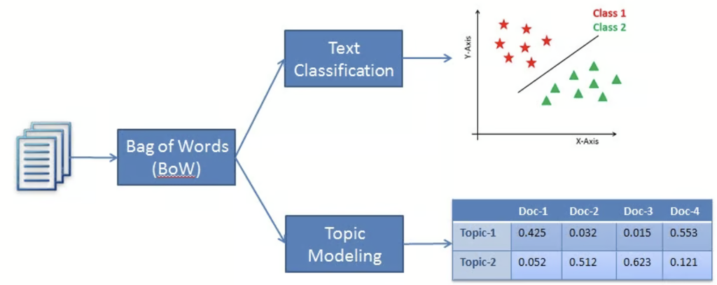

# Implementation Walkthrough

## Preprocessing Pipeline

1. Text cleaning: Demonstrate with examples:
   - Raw text: “The company’s Q3 earnings were $5.2M, up 15% year-over-year.”
   - After cleaning: “the companys q3 earnings were 5 2m up 15 year over year”
   - Explain rationale for each transformation (lowercasing, removing punctuation, etc.)
2. Tokenization: Show different approaches:
   - Simple whitespace splitting: [“the”, “companys”, “q3”…]
   - More sophisticated tokenizers that handle contractions, hyphenations, etc.
   - Highlight language-specific challenges
3. Stop word removal: Explain:
   - Definition of stop words (common words that don’t carry topical meaning)
   - Show examples: “the”, “is”, “and”, “of”, etc.
   - Demonstrate impact: reduces noise and focuses on content-bearing words
   - Caution about domain-specific stop words
4. Stemming/Lemmatization: Compare approaches:
   - Stemming: “running”, “runs”, “runner” → “run” (rule-based, faster)
   - Lemmatization: “better” → “good” (dictionary-based, more accurate)
   - Show examples of both approaches on the same text
5. N-gram consideration: Explain:
   - Unigrams miss multi-word concepts (“New York”, “machine learning”)
   - Show examples of bigrams/trigrams that preserve meaning
   - Discuss trade-offs (vocabulary explosion vs. semantic preservation)
6. **Code snippet**: Walk through a complete preprocessing pipeline in Python, highlighting key functions and parameters

## Parameter Tuning

- Number of topics (K):
  - Show examples of the same corpus modeled with different K values (e.g., 5, 20, 50)
  - Demonstrate how topics become more specific with higher K
  - Show coherence score plots for different K values
  - Discuss heuristics: sqrt(N/2) where N is number of documents
  - Explain the importance of domain expertise in this decision
- Alpha and Beta:
  - Show visualizations of different alpha values and resulting document-topic distributions
  - Similarly for beta and resulting topic-word distributions
  - Explain asymmetric priors (some topics might naturally be more common)
  - Show how to implement automatic optimization in Gensim
- Iterations/Passes:
  - Explain difference between passes (full data sweeps) and iterations (algorithm steps)
  - Show convergence plots (log-likelihood or perplexity vs. iterations)
  - Discuss diminishing returns and when to stop training
  - Provide rules of thumb for different corpus sizes

## Common Challenges

- Overfitting: Explain:
  - Signs of overfitting (topics that memorize specific documents)
  - How to address it (regularization, fewer topics, more training data)
  - Show examples of overfitted vs. well-fitted topics
- Stability: Discuss:
  - Why different random initializations lead to different results
  - Techniques for improving stability (multiple runs with consensus topics)
  - How to compare topics across runs (topic alignment methods)
- Interpretability: Address:
  - The semantic gap between statistical patterns and human understanding
  - Why some topics appear as mixtures of unrelated concepts
  - Techniques for improving interpretability (anchoring, seeding)
- Evaluation: Cover:
  - The challenge of evaluating unsupervised models
  - Intrinsic measures (perplexity, coherence) vs. extrinsic measures (task performance)
  - Human evaluation approaches and best practices
- Solutions: Provide practical advice for each challenge:
  - Ensemble methods
  - Parameter sweeps with coherence metrics
  - Interactive refinement
  - Domain-specific customizations

# Topic Interpretation & Visualization

## Interpreting Topics

- Word lists: Explain:
  - Why we look at top N words (usually 10-20) per topic
  - The importance of examining probability values, not just rankings
  - Show examples of clear vs. ambiguous topics based on word lists
- Word clouds: Discuss:
  - How word size represents probability within a topic
  - Advantages for quick visual inspection
  - Limitations (may overemphasize visual differences)
  - Show examples of effective topic word clouds
- Topic labels: Cover:
  - Process for manually assigning meaningful labels
  - Inter-annotator agreement issues
  - Best practices (concise, descriptive, consistent)
  - Show examples of good and poor labeling
- Example: Walk through a complete example:
  - Words: “patient (0.08), hospital (0.07), doctor (0.06), treatment (0.05)…”
  - Interpretation process: identifying common theme of healthcare
  - Alternative interpretations and disambiguation
- Caution: Discuss interpretation pitfalls:
  - Cherry-picking words that fit preconceived notions
  - Ignoring contradictory evidence
  - Overinterpreting noise as signal
  - Need for validation with domain experts

## LDAvis Visualization

- **Interactive visualization tool**: Explain the importance of interactive exploration for understanding complex models
- Components:
  - Left panel: Explain that each bubble represents a topic, size indicates corpus prevalence
  - Right panel: Explain term relevance calculation (combines probability and exclusivity)
  - Distance: Explain that it’s based on Jensen-Shannon divergence between topics
  - λ parameter: Explain how adjusting it changes the balance between probability and exclusivity
- Screenshot: Walk through each element in the visualization:
  - Global term frequency (blue bars)
  - Topic-specific term frequency (red bars)
  - How to identify distinctive vs. common terms
  - What topic similarity and distance mean
- Demonstration: Show how to use the visualization to:
  - Identify redundant topics (closely positioned)
  - Find unique, distinctive topics
  - Adjust λ to see different perspectives on topics
  - Interpret term relevance within topical context

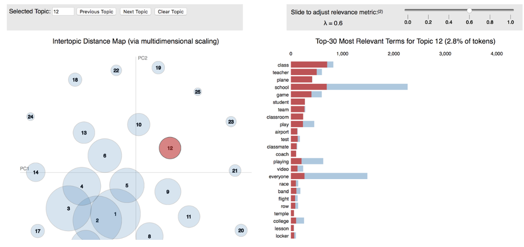

## Coherence Measures

- **Definition**: Explain that coherence measures try to quantify the semantic consistency of words within a topic
- Types of coherence:
  - UMass coherence: Explain how it uses document co-occurrence and log conditional probability
  - CV coherence: Explain how it combines multiple approaches for more human-aligned scores
  - UCI coherence: Explain how it uses external data and pointwise mutual information
  - Compare with human judgments of coherence
- Code example: Walk through Gensim implementation:
  - How to calculate different coherence measures
  - Interpreting the output values
  - Using coherence for model selection
- Interpretation: Provide guidelines:
  - Typical score ranges for different measures
  - Relative vs. absolute interpretation
  - When to trust/distrust coherence scores
  - Complementary evaluation approaches

## Interpreting Results

- Example topics from real dataset: Show a complete case study:
  - 5-6 topics from a realistic dataset (e.g., news articles)
  - Top 10 words for each topic
  - Assigned labels and justification
- Visualization of document-topic mixtures: Demonstrate:
  - Heatmap of document-topic proportions
  - Clustering documents by dominant topic
  - Identifying boundary cases (mixed-topic documents)
- Practical interpretation tips:
  - Explain how context matters (same word has different meaning in different topics)
  - Show how to use original documents to validate topic interpretations
  - Demonstrate techniques for handling polysemy and synonymy
  - Explain the importance of examining multiple related topics together
- Identify outliers or noise topics: Discuss:
  - Characteristics of “junk” topics (uniform word distributions, highly mixed topics)
  - How to handle them (filtering, retraining, parameter adjustment)
  - When they might indicate interesting edge cases

# Advanced Topics & Variations

## Dynamic Topic Models

- Purpose: Expand on how static topic models fail to capture evolution:
  - Terms change meaning over time (“cloud” pre/post-computing)
  - Topics emerge, evolve, merge, and disappear
  - Proportions shift with events and trends
- Key differences from standard LDA:
  - Explain the state-space model approach (topics evolve following sequential dependencies)
  - Describe how word distributions evolve over time slices
  - Explain how documents are grouped into time slices
- Applications: Provide concrete examples:
  - Tracking “artificial intelligence” as a research topic from 1980-2025
  - Analyzing how political discourse evolves during election cycles
  - Monitoring brand perception changes after major events
- Visual example: Walk through an example timeline showing:
  - Topic emergence (e.g., “social media” appearing in 2005-2008)
  - Term probability shifts within topics over time
  - Changes in topic prevalence through time periods

## Hierarchical Topic Models

- Structure: Explain the conceptual model:
  - Super-topics contain sub-topics in a tree structure
  - Documents can be described at multiple levels of granularity
  - Example: “Science” → “Biology” → “Genetics” → “CRISPR”
- Methods:
  - Hierarchical Dirichlet Process (HDP): Explain non-parametric approach that automatically determines number of topics at each level
  - Pachinko Allocation Model (PAM): Explain directed acyclic graph structure allowing more complex topic relationships
  - Compare advantages/disadvantages of each approach
- Advantage: Elaborate on benefits:
  - More natural representation of concept hierarchies
  - Multi-resolution analysis of document collections
  - Better handling of large, diverse corpora
  - Improved navigation of document collections
- Visual example: Show hierarchy visualization:
  - Topic tree with word distributions at each node
  - How documents propagate through the hierarchy
  - Example of zoom-in/zoom-out navigation

## Neural Topic Models

- Neural Network Approaches:
  - Variational Auto-Encoders (VAE): Explain the encoder-decoder architecture and how it relates to topic modeling
  - Neural Variational Document Model (NVDM): Explain how it learns document representations in continuous space
  - ProdLDA: Explain how it combines neural networks with LDA’s probabilistic structure
  - Discuss the relationship to word embeddings
- Advantages: Elaborate on:
  - Ability to capture semantic relationships beyond co-occurrence
  - Integration with pre-trained language models
  - Handling of larger vocabularies
  - Potentially more coherent topics
- Challenges: Discuss:
  - Increased complexity and computational requirements
  - Difficulty interpreting latent dimensions
  - Need for larger training data
  - Hyperparameter sensitivity
- Current research directions: Mention:
  - Transformer-based topic models
  - Multimodal topic modeling (text + images)
  - Zero-shot topic modeling
  - Self-supervised approaches

## Supervised Topic Models

- Incorporating labels/metadata:
  - Supervised LDA (sLDA): Explain how it jointly models documents and response variables
  - Labeled LDA: Explain how it constrains topics to align with document labels
  - Compare discriminative vs. generative approaches
- Applications: Provide concrete examples:
  - Document classification: Using topic proportions as features
  - Author-topic models: Discovering author-specific themes and interests
  - Sentiment-topic models: Learning sentiment-specific word distributions for topics
  - Geographical topic models: Discovering region-specific topics
- When to use: Discuss scenarios:
  - When prediction is the primary goal
  - When metadata provides strong priors for topic structure
  - For personalization applications
  - When interpretability needs to align with existing categories

# Applications & Case Studies

## Content Recommendation

- Application: Expand on recommendation approaches:
  - Content-based filtering using topic proportions
  - Using topic modeling to address cold-start problems
  - Hybrid systems combining collaborative and topic-based approaches
  - Explainable recommendations through topic interpretations
- Process flow: Walk through the complete pipeline:
  1. Training the topic model on content corpus (articles, products, etc.)
  2. Inferring topic distributions for user history
  3. Creating user profiles as aggregated topic vectors
  4. Computing similarity between user profiles and candidate content
  5. Ranking and presenting recommendations
- Real-world examples: Discuss implemented systems:
  - News aggregators like Google News using topics for personalization
  - Academic paper recommenders like Semantic Scholar
  - Content streaming services categorizing content
  - E-commerce product recommendation
- Advantages: Highlight key benefits:
  - Ability to explain “why” items are recommended
  - Discovery of cross-category connections
  - Privacy advantages (local processing of user preferences)
  - Addressing popularity bias in collaborative filtering

## Document Organization & Search

- Applications: Elaborate on use cases:
  - Automatic tagging: How topics can become document metadata
  - Topic-based search: Enhancing keyword search with semantic topics
  - Document summarization: Using topic proportions to identify key content
  - Faceted browsing: Using topics as navigation dimensions
- Case study: Walk through digital library implementation:
  - Initial corpus preparation and modeling
  - Integration with existing metadata
  - User interface for topic-based exploration
  - Evaluation of user experience improvements
  - Metrics showing increased engagement
- Visualization: Explain document map visualization:
  - 2D projection of documents based on topic similarity
  - Clustering and color-coding by dominant topic
  - Interactive exploration capabilities
  - How it reveals thematic structure
- Benefits: Discuss concrete improvements:
  - Quantitative metrics of improved document discovery
  - Reduced search time for information retrieval
  - Better handling of synonymy and polysemy
  - Support for exploratory search behaviors

## Trend Analysis

- Application: Expand on trend detection:
  - Early identification of emerging topics
  - Tracking topic proportion changes over time
  - Connecting topic shifts to external events
  - Predictive models based on topic trajectories
- Process: Detail the methodology:
  1. Creating appropriate time slices (daily, weekly, monthly)
  2. Training separate models or dynamic topic models
  3. Aligning topics across time periods
  4. Measuring changes in topic prevalence and content
  5. Statistical testing for significant shifts
  6. Visualizing and reporting findings
- Case study: Present COVID-19 discourse analysis:
  - Data collection from news and social media
  - Topic evolution from medical to economic to political focus
  - Correlation with pandemic timeline events
  - Regional variations in topic emphasis
  - Policy implications of the analysis
- Visual example: Walk through visualization:
  - Line graph showing topic proportion changes
  - Annotation of key events affecting discourse
  - Topic content evolution display
  - Predictive projections of future trends

## Academic Literature Mapping

- Application: Elaborate on research landscape analysis:
  - Understanding interdisciplinary connections
  - Tracking evolution of research fields
  - Identifying emergent research themes
  - Supporting literature review processes
  - Discovering potential collaborations
- Process: Explain methodology:
  - Corpus creation from abstracts, full-texts, or citations
  - Specialized preprocessing for academic text
  - Topic modeling with field-specific adjustments
  - Connecting topics to citation networks
  - Temporal analysis of research evolution
- Case study: Present computer science literature map:
  - Data from major conferences and journals
  - Identified major research areas
  - Discovered bridges between traditionally separate fields
  - Predicted emerging research frontiers
  - Usage by researchers and funding agencies
- Visual example: Explain network visualization:
  - Topics as nodes sized by publication volume
  - Edges representing topical overlap
  - Clusters indicating research communities
  - Temporal color-coding showing evolution
  - Interactive elements for exploration

# Conclusion & Resources

## Key Takeaways

- Core concepts: Reinforce fundamental principles:
  - The mixed-membership nature of documents across topics
  - The probabilistic foundations of topic modeling
  - The unsupervised nature of discovery
  - The balance between statistical and human interpretability
- LDA fundamentals: Summarize essential components:
  - The generative story and its relationship to the model
  - Critical parameters and their effects
  - Inference challenges and approaches
  - Limitations and assumptions
- Practical considerations: Highlight implementation advice:
  - Importance of preprocessing decisions
  - Parameter selection strategies
  - Evaluation approaches
  - Common pitfalls and solutions
- Applications: Remind students of the breadth of applications:
  - From social media analysis to scientific discovery
  - From content organization to trend prediction
  - Emphasize interdisciplinary nature

## Further Learning Resources

- Books: Provide context for each recommendation:
  - “Probabilistic Topic Models” by David Blei: Foundational mathematical treatment
  - “Mining the Social Web” by Matthew Russell: Practical implementation focus
  - Mention specific chapters most relevant to topic modeling
- Libraries: Compare available implementations:
  - Gensim: Python library specialized for topic modeling
  - scikit-learn: General ML library with LDA/NMF implementations
  - BERTopic: Modern neural approach combining BERT with clustering
  - Top2Vec: Embedding-based topic discovery
  - Discuss strengths and use cases for each

## Questions?

- Prepare for common questions:
  - “How many topics should I choose for my project?”
  - “How can I evaluate if my topics are good?”
  - “Can topic modeling handle short texts like tweets?”
  - “How does topic modeling compare to clustering?”
- Include contact information for further discussion
- Suggest project ideas for students to apply topic modeling
- Preview related concepts that might be covered in future sessions